# phaseTime tutorial: haplotype-specific copy number gain timing

phaseTime combines long-read and short-read whole genome sequencing (WGS) of tumour samples to

1. **phase somatic mutations to haplotypes**, using heterozygous SNPs that are on the same long reads as the mutation, and
2. **estimate the evolutionary timing of copy number gains, separately for each haplotype**, including several consecutive gains of the same segment and gains placed on the edges of a tumour phylogeny.

This tutorial walks through every step of the method on a simulated tumour. Alongside the plots produced here, schematic illustrations explain the principles, and example output from real multi-region long-read sequenced lung tumours shows what the results look like on real data.

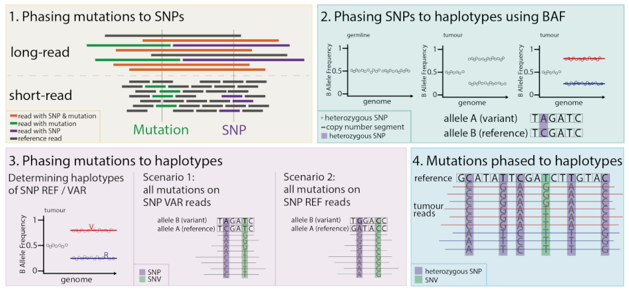

Principles of phasing mutations to haplotypes: mutations are physically linked to SNPs on long reads, SNPs are phased to haplotypes, and the mutation inherits the haplotype of its linked SNP alleles.

# Installation

```r
# install.packages("remotes")
remotes::install_github("kerstinth/phaseTime", build_vignettes = TRUE)
```

phaseTime only depends on `ggplot2` and `patchwork`.

```r
library(phaseTime)
library(ggplot2)
```

# Input data

phaseTime takes the following inputs for each tumour region (*sample*):

| input | columns | typical source |
| --- | --- | --- |
| `mutations` | `sample`, `chr`, `pos`, `vaf` (or `var_count`, `depth`), optionally `cluster` | Mutect2 calls from paired short-read WGS |
| `cn` | `sample`, `chr`, `seg_start`, `seg_end`, major / minor copy number | Battenberg on short-read WGS |
| `purity` | named vector, one value per sample | Battenberg |
| `snps` | `region`, `chr`, `pos`, `baf` of heterozygous germline SNPs | SNP calling / Battenberg allele counts |
| `linkage` | `sample`, `chr`, `pos`, `snp_pos`, `mt_snp_alt`, `mt_snp_ref` | pileup of Nanopore long reads (Dorado, minimap2 to GRCh38) |
| `tree` | edges (parent, child) and trunk | CONIPHER on short-read WGS |

`linkage` contains, for every mutation and nearby heterozygous SNP, the number of long reads that carry the mutation **and** the alternative (`mt_snp_alt`) or reference (`mt_snp_ref`) allele of the SNP.

To make this tutorial self-contained we simulate a tumour with two regions with `simulate_tumour()`. Mutations are acquired on individual DNA copies along the phylogeny `1 -> 2 -> 3` and `1 -> 4 -> 5` (cluster 2 is clonal in region 1, cluster 4 in region 2), and copy number gains duplicate DNA copies together with the mutations they carry. The simulated reads mimic a typical long-read study (~200x short-read and ~17x long-read coverage). Because the gain times are known, we can check the estimates against the truth.

```r
sim <- simulate_tumour(seed = 1)
names(sim)
```

```
#> [1] "mutations" "cn"        "snps"      "linkage"   "purity"    "tree"
#> [7] "truth"
```

```r
head(sim$mutations[, c("sample", "chr", "pos", "ref", "alt", "var_count", "depth", "vaf", "cluster")])
```

```
#>      sample  chr      pos ref alt var_count depth       vaf cluster
#> 1 SIM001_R1 chr1 10914802   C   G       131   211 0.6208531       1
#> 2 SIM001_R1 chr1 25932362   G   A       131   213 0.6150235       1
#> 3 SIM001_R1 chr1 18487166   A   T       140   208 0.6730769       1
#> 4 SIM001_R1 chr1 54304392   C   G       126   203 0.6206897       1
#> 5 SIM001_R1 chr1 81994754   G   C       104   192 0.5416667       1
#> 6 SIM001_R1 chr1 49001200   C   G       118   189 0.6243386       1
```

```r
head(sim$cn[, c("sample", "chr", "seg_start", "seg_end", "nMajor", "nMinor")])
```

```
#>      sample  chr seg_start   seg_end nMajor nMinor
#> 1 SIM001_R1 chr1         1 102193308      3      1
#> 2 SIM001_R1 chr1 102193309 248956422      1      0
#> 3 SIM001_R1 chr2         1 242193529      1      1
#> 4 SIM001_R1 chr3         1  57739176      2      0
#> 5 SIM001_R1 chr3  57739177 154447013      4      1
#> 6 SIM001_R1 chr3 154447014 198295559      2      1
```

```r
head(sim$snps[, c("region", "chr", "pos", "baf")])
```

```
#>      region  chr    pos       baf
#> 1 SIM001_R1 chr1   1784 0.7272727
#> 2 SIM001_R1 chr1  33879 0.7262570
#> 3 SIM001_R1 chr1 111767 0.7327189
#> 4 SIM001_R1 chr1 119144 0.7524752
#> 5 SIM001_R1 chr1 120435 0.7336683
#> 6 SIM001_R1 chr1 121217 0.7211538
```

```r
head(sim$linkage)
```

```
#>      sample  chr      pos  snp_pos mt_snp_alt mt_snp_ref
#> 1 SIM001_R1 chr1 25932362 25933463          0          5
#> 2 SIM001_R1 chr1 25932362 25930705          6          0
#> 3 SIM001_R1 chr1 25932362 25930550          0          6
#> 4 SIM001_R1 chr1 18487166 18489363          0          9
#> 5 SIM001_R1 chr1 54304392 54302251          0         11
#> 6 SIM001_R1 chr1 81994754 81992765          1          8
```

```r
sim$purity
```

```
#> SIM001_R1 SIM001_R2
#>      0.70      0.55
```

```r
sim$tree
```

```
#> $edges
#>      parent child
#> [1,] "1"    "2"
#> [2,] "2"    "3"
#> [3,] "1"    "4"
#> [4,] "4"    "5"
#>
#> $trunk
#> [1] "1"
```

# Step 1: phasing mutations to SNPs

Long reads can carry both a somatic mutation and a heterozygous SNP. Simulating random positions of 50,000 mutations and 2.25 million heterozygous SNPs shows how much longer reads increase the fraction of mutations that can be phased: about 10% with 150 bp reads, but almost all with 5 kb reads.

```r
phasing_sim <- simulate_snp_phasing(seed = 1)
phasing_sim
```

```
#>    read_length number_mutations number_phased_muts pct_phased
#> 1          100            50000               3591      7.182
#> 2          150            50000               5391     10.782
#> 3          200            50000               6920     13.840
#> 4          300            50000               9926     19.852
#> 5          500            50000              15223     30.446
#> 6         1000            50000              26030     52.060
#> 7         2000            50000              38612     77.224
#> 8         5000            50000              48762     97.524
#> 9         7500            50000              49801     99.602
#> 10       10000            50000              49976     99.952
```

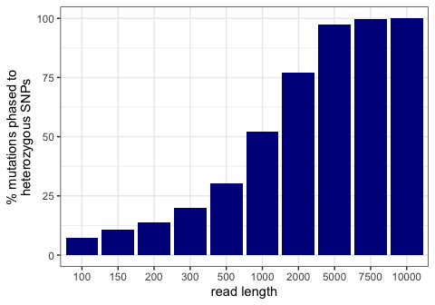

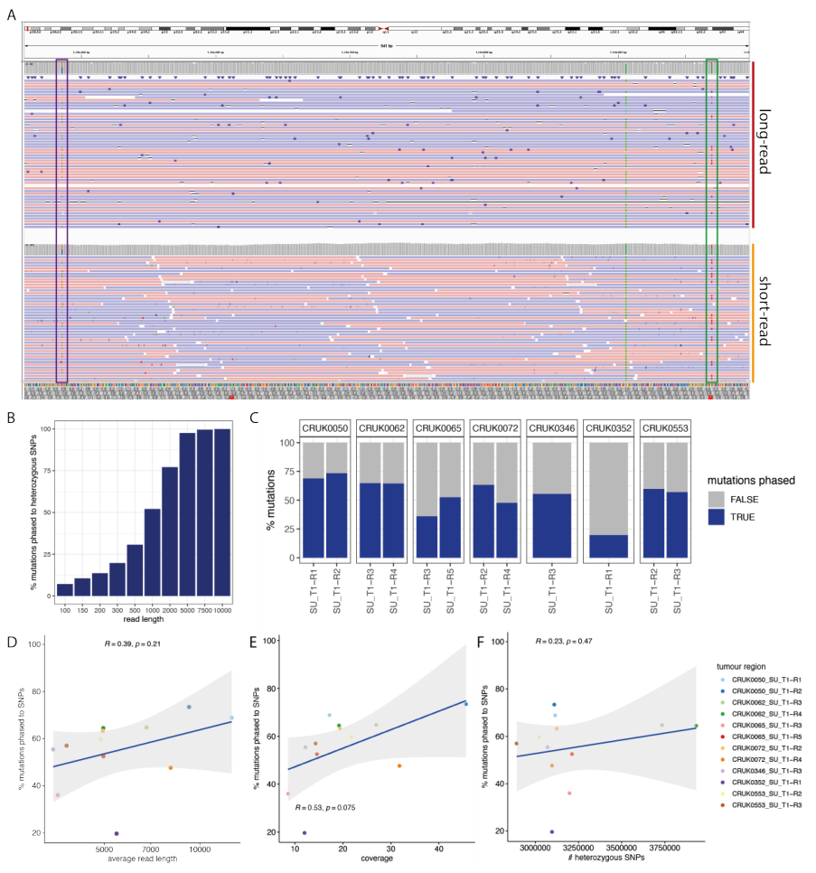

Example from real data: (A) a mutation and a heterozygous SNP on the same long reads; (B) the simulation above; (C-F) percentage of mutations phased to SNPs per tumour region and its relation to read length, coverage and number of heterozygous SNPs.

```r
plot_snp_phasing_simulation(phasing_sim)
```

To reduce run time, only the 16 SNPs closest to each mutation (within 20 kb) are considered. `select_phasing_snps()` creates this list of mutation-SNP pairs that is then counted in the long-read BAM file (e.g. with `samtools mpileup`), discarding loci with fewer than 3 reads, to produce the `linkage` table.

```r
r1_snps <- unique(sim$snps[sim$snps$region == "SIM001_R1", c("chr", "pos")])
r1_muts <- sim$mutations[sim$mutations$sample == "SIM001_R1", ]
pairs <- select_phasing_snps(r1_muts, r1_snps, max_snps = 16, max_distance = 20000)
head(pairs)
```

```
#>    chr      pos  snp_pos distance
#> 1 chr1 10914802 10912428     2374
#> 2 chr1 10914802 10930498    15696
#> 3 chr1 10914802 10931016    16214
#> 4 chr1 10914802 10932885    18083
#> 5 chr1 10914802 10933242    18440
#> 6 chr1 10914802 10933860    19058
```

# Step 2: phasing SNPs to haplotypes

In a segment with allelic imbalance the B-allele frequency (BAF) of a heterozygous SNP deviates from 0.5. SNPs whose alternative allele is on the more abundant haplotype have BAF > 0.5; this haplotype is called **haplotype A**, the other **haplotype B**.

With several tumour regions, a segment can be phased as long as *one* region is imbalanced: `phase_snps()` uses the region with the strongest allelic imbalance as the reference and applies its SNP haplotypes to all regions.

```r
cn_long <- sim$cn
cn_long$region <- cn_long$sample
snps_phased <- phase_snps(sim$snps, cn = cn_long)
head(snps_phased[, c("region", "chr", "pos", "baf", "ref_region", "single_region_haplotype", "haplotype")])
```

```
#>      region  chr    pos       baf ref_region single_region_haplotype haplotype
#> 1 SIM001_R1 chr1   1784 0.7272727  SIM001_R1                       A         A
#> 2 SIM001_R1 chr1  33879 0.7262570  SIM001_R1                       A         A
#> 3 SIM001_R1 chr1 111767 0.7327189  SIM001_R1                       A         A
#> 4 SIM001_R1 chr1 119144 0.7524752  SIM001_R1                       A         A
#> 5 SIM001_R1 chr1 120435 0.7336683  SIM001_R1                       A         A
#> 6 SIM001_R1 chr1 121217 0.7211538  SIM001_R1                       A         A
```

In region 1, chromosomes 11, 15 and 22 are balanced (BAF ~ 0.5) and cannot be phased from region 1 alone (top), but region 2 carries a gain there, so the multi-region haplotypes phase them (bottom).

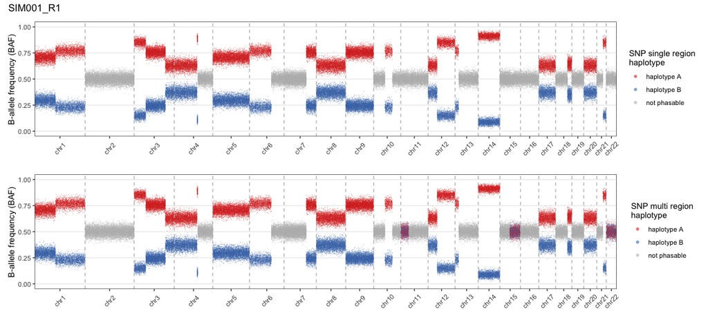

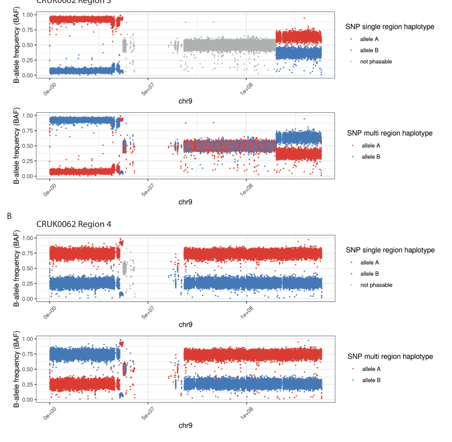

Example from real data: single-region (top) and multi-region (bottom) SNP phasing of two regions of the same tumour.

```r
plot_snp_haplotypes(snps_phased, region = "SIM001_R1")
```

# Step 3: haplotype copy number and mutation multiplicity

Battenberg reports major and minor copy numbers. `haplotype_copy_number()` assigns them to haplotypes A and B using the phased SNPs, so that copy number and mutations refer to the same haplotypes in every region. For subclonal segments, `battenberg_average_cn()` averages the clone states by their cellular fractions (resulting in non-integer copy numbers).

```r
cn_r1 <- haplotype_copy_number(sim$cn[sim$cn$sample == "SIM001_R1", ],
                               snps = snps_phased[snps_phased$region == "SIM001_R1", ])
head(cn_r1[, c("chr", "seg_start", "seg_end", "nMajor", "nMinor", "flip", "cnA", "cnB")])
```

```
#>    chr seg_start   seg_end nMajor nMinor  flip cnA cnB
#> 1 chr1         1 102193308      3      1 FALSE   3   1
#> 2 chr1 102193309 248956422      1      0 FALSE   1   0
#> 3 chr2         1 242193529      1      1 FALSE   1   1
#> 4 chr3         1  57739176      2      0 FALSE   2   0
#> 5 chr3  57739177 154447013      4      1 FALSE   4   1
#> 6 chr3 154447014 198295559      2      1 FALSE   2   1
```

Next, the mutation multiplicity (the number of DNA copies carrying a mutation) is computed from the VAF, the purity `p` and the total copy number `CN_t` (normal copy number `CN_n` = 2):

$$n_{mut} = VAF \cdot \frac{1}{p}
\left[p\,CN_t + CN_n (1 - p)\right]$$

```r
muts_r1 <- annotate_mutations(sim$mutations[sim$mutations$sample == "SIM001_R1", ],
                              cn_r1, purity = sim$purity[["SIM001_R1"]])
head(muts_r1[, c("chr", "pos", "vaf", "cnA", "cnB", "tot_cn", "mut_cpn")])
```

```
#>    chr      pos       vaf cnA cnB tot_cn  mut_cpn
#> 1 chr1 10914802 0.6208531   3   1      4 3.015572
#> 2 chr1 25932362 0.6150235   3   1      4 2.987257
#> 3 chr1 18487166 0.6730769   3   1      4 3.269231
#> 4 chr1 54304392 0.6206897   3   1      4 3.014778
#> 5 chr1 81994754 0.5416667   3   1      4 2.630952
#> 6 chr1 49001200 0.6243386   3   1      4 3.032502
```

# Step 4: phasing mutations to haplotypes

For every SNP on the same long reads as a mutation, phaseTime computes the fraction of mutated reads that carry the SNP alternative allele. Using the SNP haplotype, this becomes the fraction of mutated reads on haplotype A (one minus the fraction for SNPs whose alternative allele is on haplotype B). The mean across SNPs decides the haplotype of the mutation: A if >= 0.5, otherwise B.

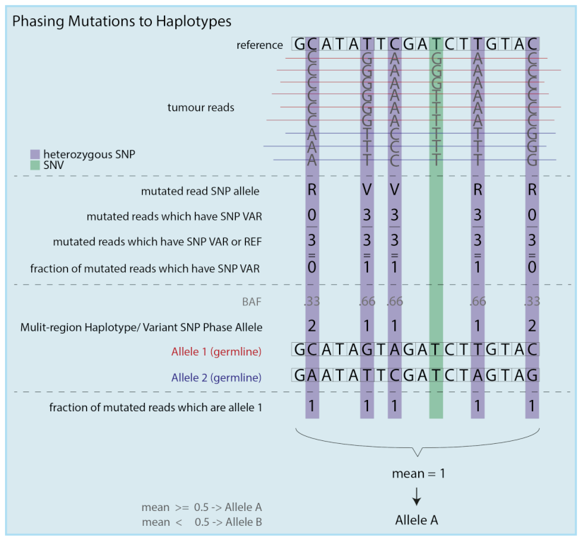

Phasing mutations using the haplotypes of physically linked SNPs.

```r
phased_r1 <- phase_mutations(sim$linkage[sim$linkage$sample == "SIM001_R1", ], snps_phased, muts_r1)
table(phase = phased_r1$phase, useNA = "ifany")
```

```
#> phase
#>     A     B  <NA>
#> 14716  5285 26160
```

In regions of loss of heterozygosity one haplotype has copy number 0, so any mutation phased to it must be wrong. `phasing_summary()` uses this to estimate the phasing error:

```r
phasing_summary(phased_r1)
```

```
#>              sample n_mutations n_phased pct_phased n_loh_phased n_incorrect
#> SIM001_R1 SIM001_R1       46161    20001   43.32878         3777          10
#>           pct_incorrect pct_incorrect_loh
#> SIM001_R1    0.02166331         0.2647604
```

The simulation also records the true haplotype, which confirms the accuracy:

```r
with(phased_r1[!is.na(phased_r1$phase), ], mean(phase == true_phase))
```

```
#> [1] 0.9940003
```

`plot_phased_mutations()` shows five views of a tumour region: copy number only, all mutations, mutations coloured by haplotype, and haplotype A or B mutations only.

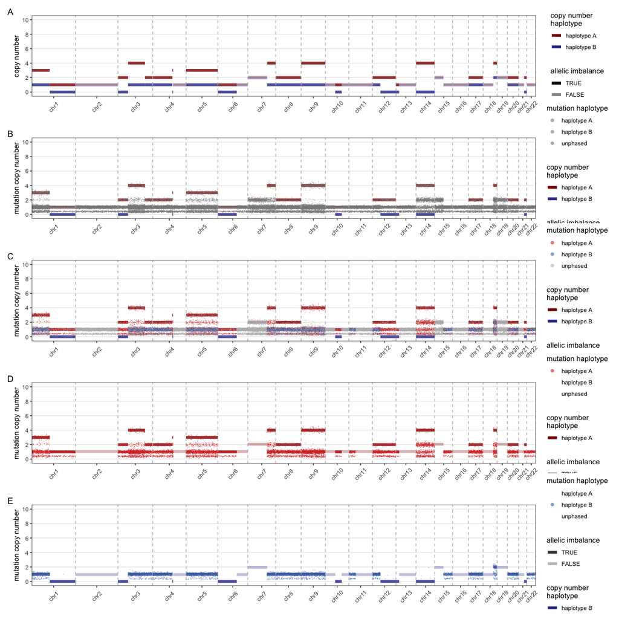

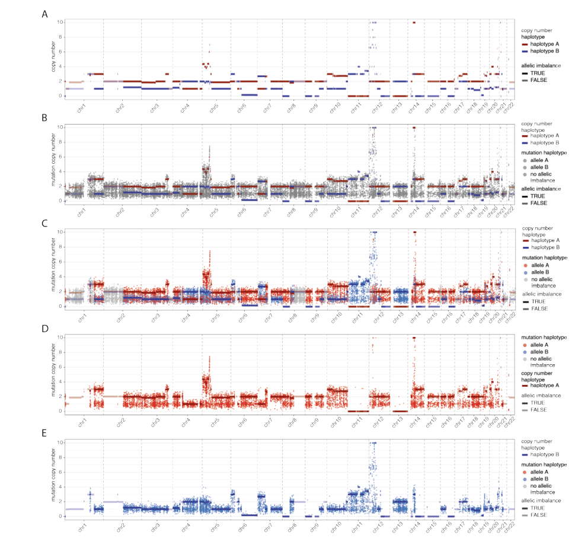

Example from real data: the same five views (A-E) for a lung tumour region.

```r
p_types <- c("copy_number", "all", "haplotype", "A", "B")
patchwork::wrap_plots(lapply(p_types, function(t) plot_phased_mutations(phased_r1, cn_r1, type = t)),
                      ncol = 1) + patchwork::plot_annotation(tag_levels = "A")
```

All plots also work for single chromosomes:

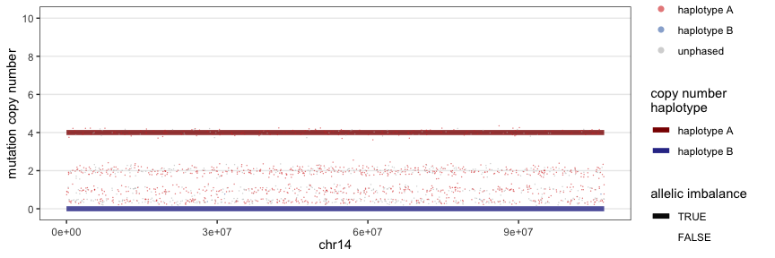

```r
plot_phased_mutations(phased_r1, cn_r1, type = "haplotype", chr = "chr14")
```

# Step 5: early and late mutations

On a gained segment, a mutation acquired **before** the gain was copied with the segment, so its multiplicity equals the haplotype copy number (**early**). A mutation acquired **after** the gain is only on some copies (**late**). `classify_mutation_timing()` rounds multiplicities and compares them with the copy number of the haplotype the mutation is on. Only clonal (integer) gained haplotypes can be timed.

```r
phased_r1 <- classify_mutation_timing(phased_r1)
table(phased_r1$timing)
```

```
#>
#>        early         late not_possible
#>         1368        11482        33311
```

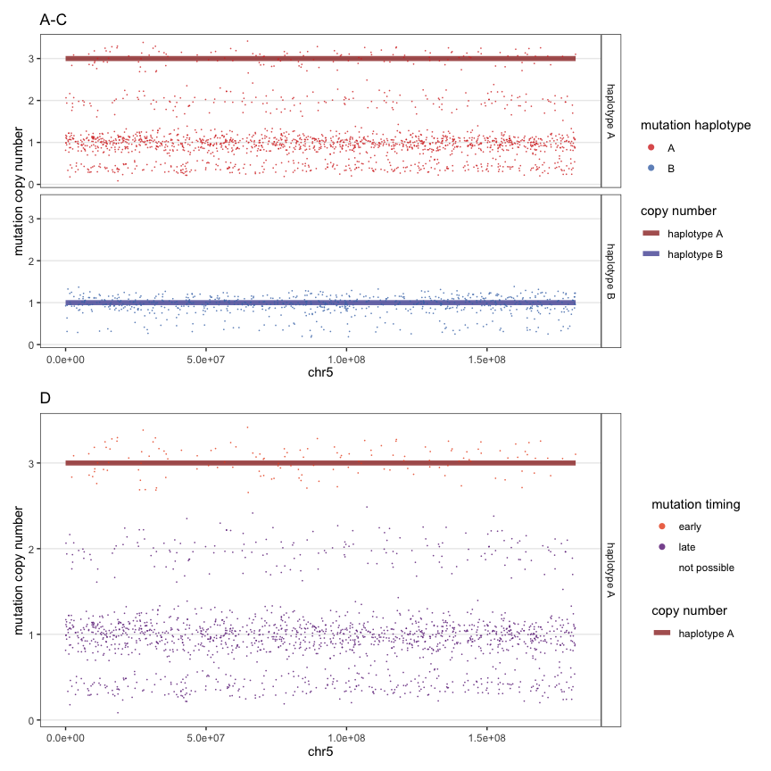

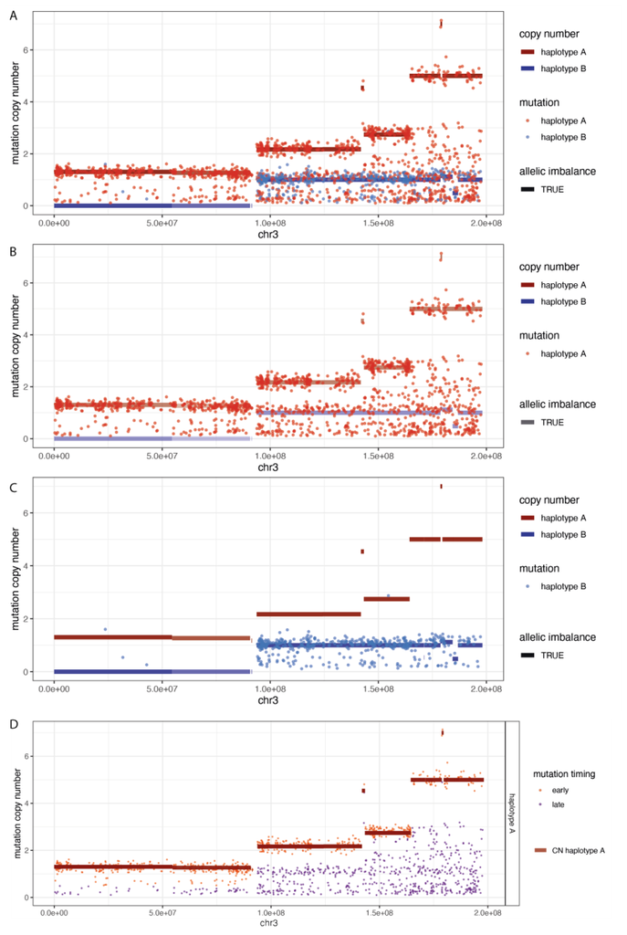

Example from real data: mutations on one chromosome by haplotype (A-C) and early (orange) / late (purple) mutations on haplotype A (D).

```r
(plot_mutation_timing(phased_r1, chr = "chr5", colour_by = "haplotype") + ggtitle("A-C")) /
  (plot_mutation_timing(phased_r1, chr = "chr5", haplotypes = "A") + ggtitle("D"))
```

Note how separating the haplotypes matters: without phasing, the haplotype B mutations at multiplicity 1 would be counted as *late* mutations of the haplotype A gain, making the gain appear earlier than it was.

# Step 6: ancestral copy number states

On segments with several consecutive gains, multiplicities cluster at integer values below the observed copy number. Each such cluster marks an *ancestral* copy number state that existed before a later gain. `assign_cn_states()` assigns mutations to the closest integer state and removes states supported by fewer than 5 mutations.

On chromosome 5 the simulated haplotype A was gained twice (1 -> 2 -> 3), and the mutations form three states:

```r
phased_r1 <- assign_cn_states(phased_r1, min_muts = 5)
table(state = phased_r1$cn_state[phased_r1$chr == "chr5" & phased_r1$phase %in% "A"])
```

```
#> state
#>    1    2    3
#> 1189  175  139
```

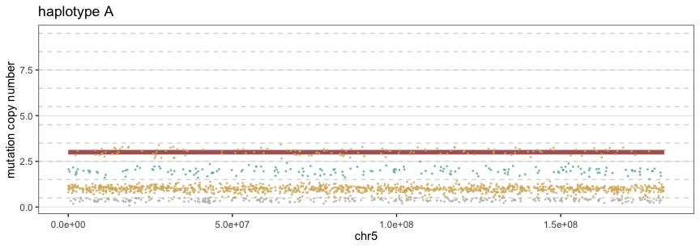

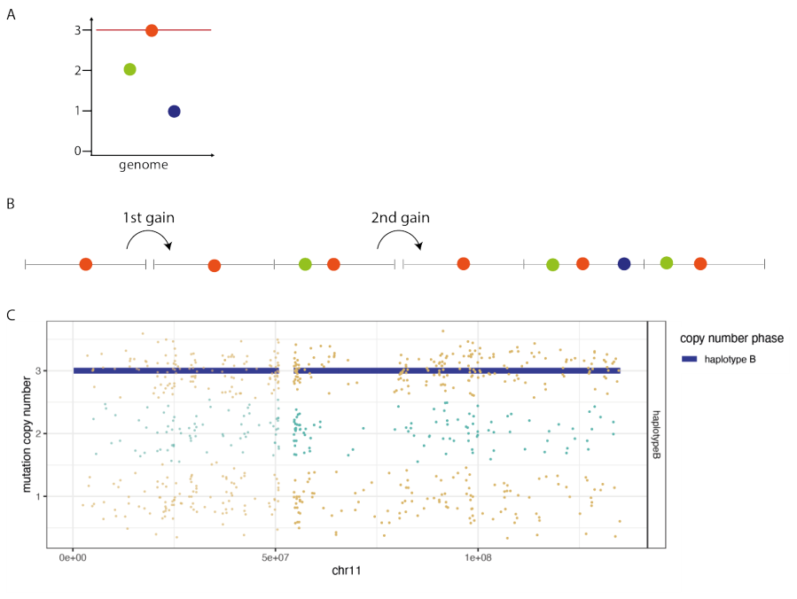

Ancestral copy number states: (A, B) a gain history that results in mutations at multiplicities 1, 2 and 3 on a segment with copy number 3; (C) an example from real data.

```r
plot_cn_states(phased_r1, haplotype = "A", chr = "chr5")
```

# Step 7: timing copy number gains

The relative numbers of early and late mutations tell us when a gain occurred: few early mutations mean an early gain, many a late one.

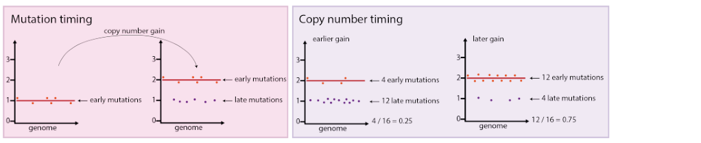

Principles of timing copy number gains.

Because more DNA copies accumulate more mutations, each mutation count is divided by the number of copies present when the mutations were acquired. The timing of a gain is then the copy number adjusted number of mutations acquired before the gain, divided by all adjusted mutations. A value of 0 means the gain happened at the start of tumour evolution and 1 means it happened at the time of sampling. The 95% confidence interval is $T \pm 1.96\sqrt{T(1-T)/N}$.

The worked example below (one mutation before the first gain, two between the gains, three after the second gain) gives timings of 1/3 and 2/3:

```r
gain_timing_from_counts(states = c(3, 2, 1), counts = c(1, 2, 3))
```

```
#>   gain_index copy_number_before_gain copy_number_after_gain
#> 1          1                       1                      2
#> 2          2                       2                      3
#>   number_early_muts_cn_adjusted number_all_muts_cn_adjusted gain_timing
#> 1                             1                           3   0.3333333
#> 2                             2                           3   0.6666667
#>          se     loCI     hiCI
#> 1 0.2721655 0.000000 0.866768
#> 2 0.2721655 0.133232 1.000000
```

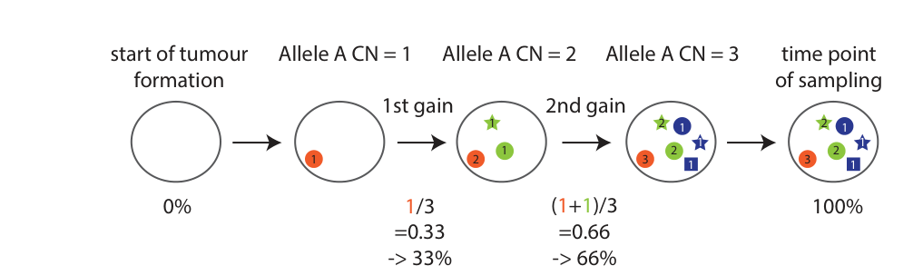

Estimating the timing of first and subsequent gains: late mutations are divided by the number of copies present when they occurred.

# Step 8: validating the timing by simulation

`simulate_gain_history()` follows a DNA segment over 10,000 cell divisions. Mutations are drawn from a Poisson distribution whose rate is proportional to the current copy number, and gains happen after specified numbers of divisions, so the true timing of each gain is known.

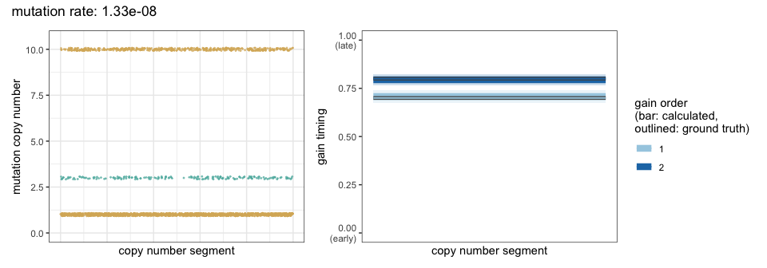

```r
set.seed(11)
scenario_a <- simulate_gain_history(timepoints = c(7000, 8000, 10000), cn_steps = c(1, 3, 10, 10))
plot_simulated_gain_timing(scenario_a)
```

```r
scenario_b <- simulate_gain_history(timepoints = c(1000, 2000, 5000, 10000), cn_steps = c(1, 2, 3, 5, 5))
simulated_gain_timing(scenario_b)[, c("gain_index", "copy_number_before_gain", "copy_number_after_gain",
                                      "gain_timing", "loCI", "hiCI", "theoretical_gain_timing")]
```

```
#>   gain_index copy_number_before_gain copy_number_after_gain gain_timing
#> 1          1                       1                      2   0.1172849
#> 2          2                       2                      3   0.2177100
#> 3          3                       3                      5   0.5123882
#>         loCI      hiCI theoretical_gain_timing
#> 1 0.09313829 0.1414314                     0.1
#> 2 0.18673959 0.2486804                     0.2
#> 3 0.47487703 0.5498994                     0.5
```

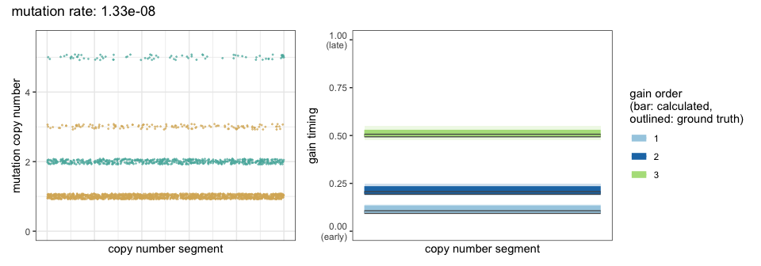

```r
plot_simulated_gain_timing(scenario_b)
```

Repeating this for 1,000 random scenarios (1 to 5 gains, copy numbers up to 10) at three mutation rates shows that the estimates are accurate (median absolute error < 0.01 at 1.33e-8 per bp) but become very uncertain at low mutation rates:

```r
acc <- simulate_gain_timing_accuracy(n_sim = 1000, seed = 1)
tapply(acc$abs_difference, acc$mutation_rate_bp, median)
```

```
#>    1.33e-10    1.33e-09    1.33e-08
#> 0.058032626 0.019593310 0.005530813
```

```r
tapply(acc$ci_width, acc$mutation_rate_bp, median)
```

```
#>   1.33e-10   1.33e-09   1.33e-08
#> 0.54051733 0.20864020 0.06542555
```

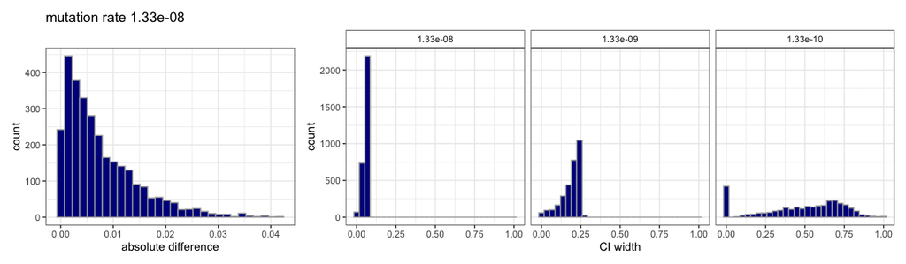

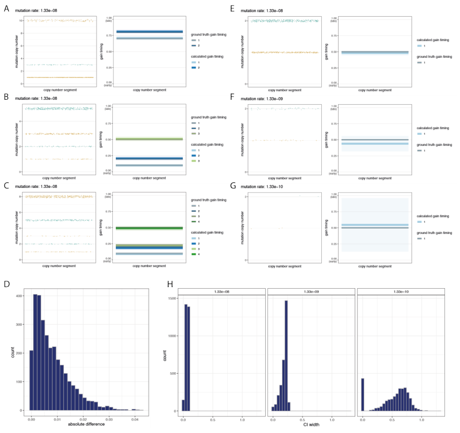

Reference results of the same simulations: example scenarios (A-C, E-G), absolute error (D) and confidence interval widths (H).

```r
plot_gain_timing_accuracy(acc)
```

# Step 9: timing clonal gains across the genome

`time_gains()` brings everything together. For every clonal gained segment and each haplotype it

1. assigns phased mutations to copy number states (per mutation cluster),
2. reconstructs the copy number path of the segment from the states,
3. times every gain between consecutive states, and
4. when a tree is given, keeps a gain of an ancestral cluster only if the same gain is not also seen in a descendant cluster, where it actually happened.

To time clonal gains, only the mutations of the trunk cluster are used:

```r
timing_r1 <- time_gains(phased_r1, cluster_col = "cluster", tree = sim$tree, sample = "SIM001_R1")
head(timing_r1[, c("segID", "haplotype", "cluster", "gain_index", "copy_number_before_gain",
                   "copy_number_after_gain", "n_mutations", "gain_timing", "loCI", "hiCI")])
```

```
#>                      segID haplotype cluster gain_index copy_number_before_gain
#> 1         chr1_1_102193308         A       1          1                       1
#> 2         chr1_1_102193308         A       1          2                       2
#> 3          chr3_1_57739176         A       1          1                       1
#> 4  chr3_57739177_154447013         A       1          1                       1
#> 5  chr3_57739177_154447013         A       1          2                       2
#> 6 chr3_154447014_198295559         A       1          1                       1
#>   copy_number_after_gain n_mutations gain_timing      loCI      hiCI
#> 1                      2         446   0.6427245 0.5854776 0.6999713
#> 2                      3         446   0.7003096 0.6455804 0.7550388
#> 3                      2         291   0.3743017 0.3034068 0.4451966
#> 4                      2         721   0.3169811 0.2609592 0.3730031
#> 5                      4         721   0.4811321 0.4209751 0.5412890
#> 6                      2         194   0.4724409 0.3856138 0.5592681
```

`plot_gain_timing()` produces a genome-wide summary: copy number; haplotype A mutations (yellow: before the first gain, blue: after the first gain, grey: not timed); haplotype A gain timing with 95% confidence intervals; and the same for haplotype B.

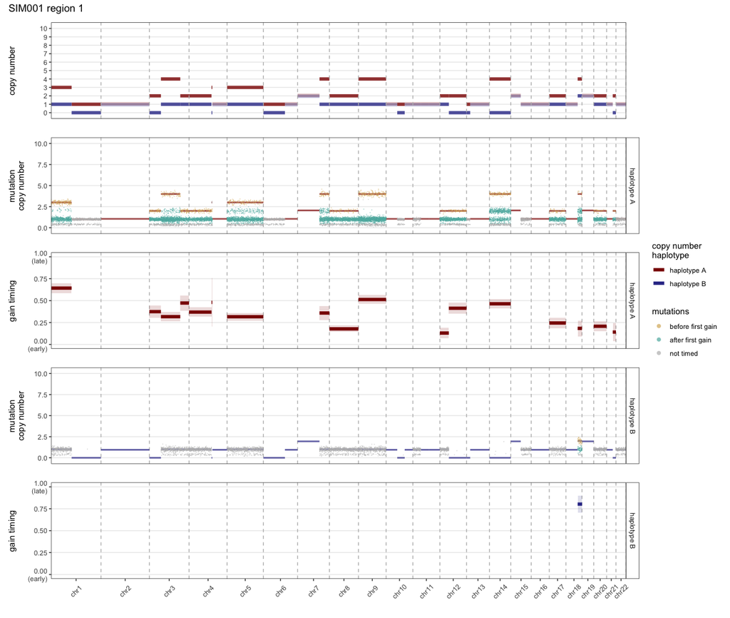

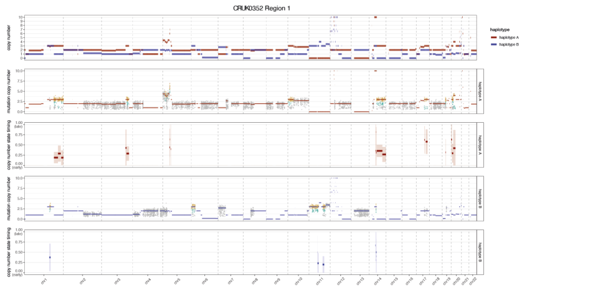

Example from real data: gain timing output for a lung tumour region.

```r
plot_gain_timing(timing_r1, phased_r1, cn_r1, title = "SIM001 region 1")
```

Since this is simulated data, the estimates can be compared with the true gain times:

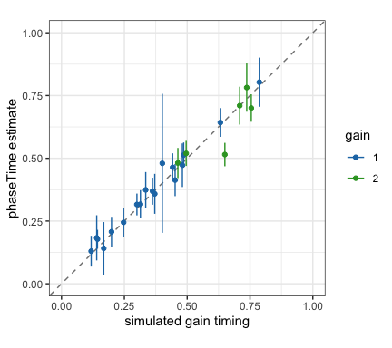

```r
key <- function(d) paste(d$segID, d$haplotype, d$cluster, d$copy_number_before_gain, d$copy_number_after_gain)
timing_r1$truth <- sim$truth$true_timing[match(key(timing_r1), key(sim$truth))]
ggplot(timing_r1[!is.na(timing_r1$truth), ], aes(truth, gain_timing, colour = factor(gain_index))) +
  geom_abline(linetype = 2, colour = "grey50") +
  geom_errorbar(aes(ymin = loCI, ymax = hiCI), width = 0) + geom_point() +
  scale_colour_manual(name = "gain", values = gain_colours(4)[c(2, 4, 6)]) +
  coord_equal(xlim = c(0, 1), ylim = c(0, 1)) +
  labs(x = "simulated gain timing", y = "phaseTime estimate") + theme_bw()
```

First gains are recovered accurately. Second gains of the form 2 -> 3 are estimated somewhat too early in this simulation: here the gain duplicates only one of the two copies, so only half of the mutations acquired between the two gains reach the higher multiplicity.

## Multi-region analysis

`run_phaseTime()` runs all steps above for every region at once, including the multi-region SNP phasing:

```r
res <- run_phaseTime(sim$mutations, sim$cn, sim$purity, sim$snps, sim$linkage,
                     cluster_col = "cluster", tree = sim$tree)
names(res)
```

```
#> [1] "snps"      "cn"        "mutations" "timing"    "phasing"
```

```r
res$phasing
```

```
#>              sample n_mutations n_phased pct_phased n_loh_phased n_incorrect
#> SIM001_R1 SIM001_R1       46161    20001   43.32878         3777          10
#> SIM001_R2 SIM001_R2       46494    19900   42.80122         3861           5
#>           pct_incorrect pct_incorrect_loh
#> SIM001_R1    0.02166331         0.2647604
#> SIM001_R2    0.01075408         0.1295001
```

The first clonal gains of all regions can be summarised as a heatmap, and gains timed independently in two regions of the same tumour can be compared:

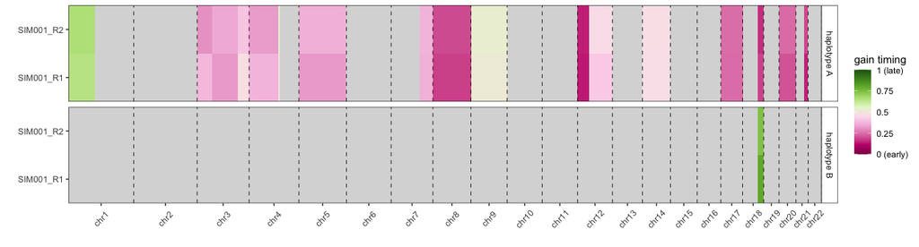

```r
plot_timing_heatmap(res$timing)
```

```r
comparison <- compare_region_timing(res$timing)
median(comparison$difference)
```

```
#> [1] 0.01909525
```

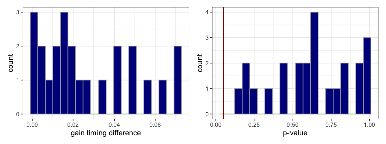

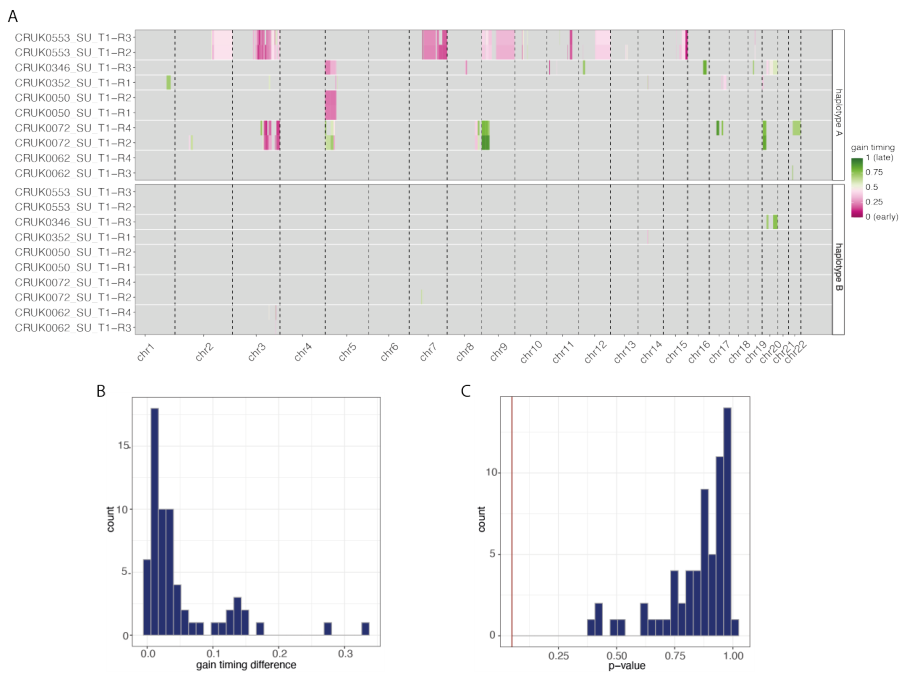

Example from real data: first clonal gain timing across ten regions of lung tumours (A) and concordance between regions of the same tumour (B, C).

```r
plot_region_comparison(comparison)
```

# Step 10: placing gains on the phylogenetic tree

With mutation clusters and a phylogenetic tree, gains can be timed within the subclonal expansion in which they happened. Use `clonal_only = FALSE` to also return gains of subclonal clusters.

In the simulated tumour, haplotype A of chromosome 14 was gained in the trunk (1 -> 2 copies) after 44% of the trunk’s evolutionary time, and doubled again (2 -> 4 copies) in cluster 2 after 30% of cluster 2’s evolutionary time, while haplotype B was lost. The trunk mutations sit at multiplicity 4 (before the trunk gain) or 2 (after), and the cluster 2 mutations at 2 (before the cluster 2 doubling) or 1 (after):

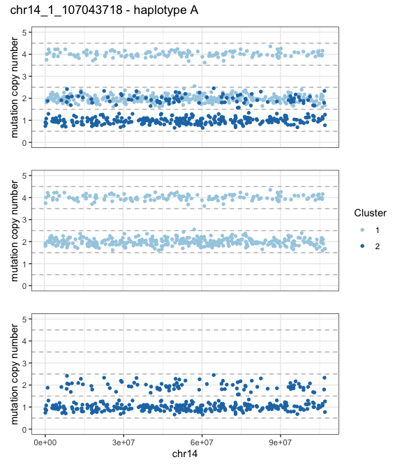

```r
plot_cluster_segment(phased_r1, "chr14_1_107043718", haplotype = "A", clusters = c("1", "2"))
```

```r
timing_tree <- time_gains(phased_r1, cluster_col = "cluster", tree = sim$tree, clonal_only = FALSE)
timing_tree[timing_tree$segID == "chr14_1_107043718",
            c("haplotype", "cluster", "copy_number_before_gain", "copy_number_after_gain", "gain_timing")]
```

```
#>    haplotype cluster copy_number_before_gain copy_number_after_gain gain_timing
#> 18         A       1                       1                      2   0.4638158
#> 19         A       2                       2                      4   0.3879310
```

```r
sim$truth[sim$truth$segID == "chr14_1_107043718", ]
```

```
#>                segID haplotype cluster copy_number_before_gain
#> 24 chr14_1_107043718         A       1                       1
#> 25 chr14_1_107043718         A       2                       2
#>    copy_number_after_gain true_timing
#> 24                      2       0.442
#> 25                      4       0.300
```

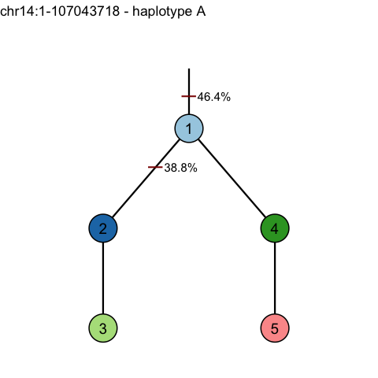

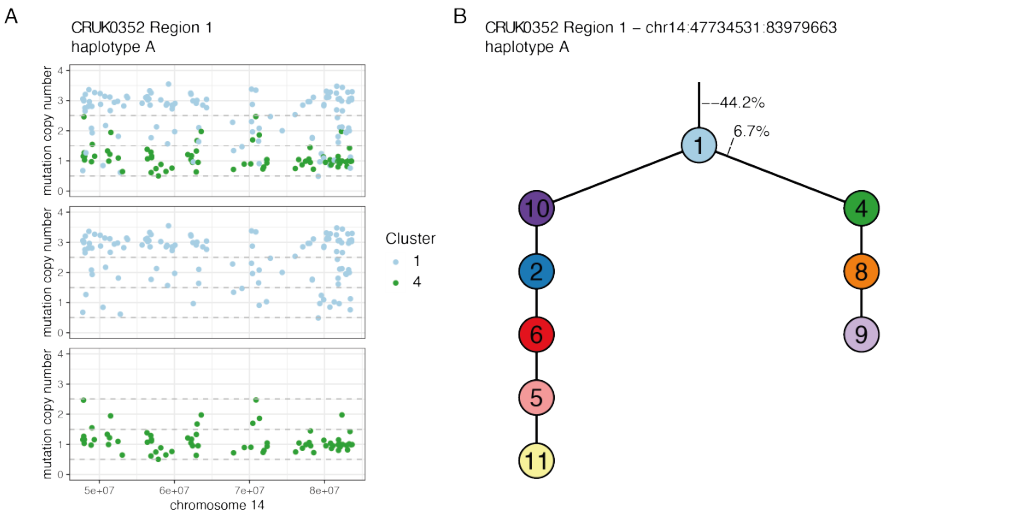

Example from real data: two gains of the same segment, one in the trunk and one in a subclone, placed on the tumour phylogeny.

```r
plot_timing_tree(sim$tree, timing_tree, "chr14_1_107043718", haplotype = "A")
```

Gains seen only in region 2 (cluster 4) are placed on the edge leading to cluster 4:

```r
m2 <- res$mutations[res$mutations$sample == "SIM001_R2", ]
t2 <- time_gains(m2, cluster_col = "cluster", tree = sim$tree, clonal_only = FALSE, sample = "SIM001_R2")
t2[t2$cluster == "4", c("segID", "haplotype", "copy_number_before_gain", "copy_number_after_gain", "gain_timing")]
```

```
#>                       segID haplotype copy_number_before_gain
#> 3  chr1_102193309_248956422         A                       1
#> 13         chr6_1_107764224         A                       1
#> 19         chr11_1_40323325         A                       1
#> 23 chr15_49716226_101991189         A                       1
#> 30         chr22_1_50818468         A                       1
#>    copy_number_after_gain gain_timing
#> 3                       2  0.06315789
#> 13                      2  0.42328042
#> 19                      2  0.21621622
#> 23                      2  0.12121212
#> 30                      2  0.51612903
```

```r
sim$truth[sim$truth$cluster == "4", ]
```

```
#>                       segID haplotype cluster copy_number_before_gain
#> 3  chr1_102193309_248956422         A       4                       1
#> 13         chr6_1_107764224         A       4                       1
#> 21         chr11_1_40323325         A       4                       1
#> 28 chr15_49716226_101991189         A       4                       1
#> 37         chr22_1_50818468         A       4                       1
#>    copy_number_after_gain true_timing
#> 3                       2       0.071
#> 13                      2       0.419
#> 21                      2       0.265
#> 28                      2       0.141
#> 37                      2       0.549
```

# Using your own data

A typical analysis of Battenberg / CONIPHER output looks like this:

```r
# copy number: average subclonal states, keep a sample column
cn <- do.call(rbind, lapply(regions, function(r) {
  bb <- read.table(paste0(r, "_subclones.txt"), header = TRUE)
  cbind(sample = r, battenberg_average_cn(bb))
}))

# alternatively use Battenberg's multi-region haplotypes directly:
# flips <- parse_battenberg_msai(read.table("multisample_MSAI.txt", header = TRUE))
# cn_r1 <- haplotype_copy_number(cn[cn$sample == "R1", ], flip = flips[flips$region == "R1", ])

purity <- c(R1 = 0.62, R2 = 0.48)
tree <- as_phaseTime_tree(readRDS("tumour.tree.RDS"))  # CONIPHER tree object

res <- run_phaseTime(mutations, cn, purity, snps, linkage,
                     cluster_col = "cluster", tree = tree, output_dir = "phaseTime_output")
```

# Notes on the implementation

- **Count adjustment.** By default (`adjust = "copies_present"`) mutation counts are divided by the number of copies present while the mutations were acquired, as described above and validated by the simulations. An alternative is to divide the counts by the multiplicity of each state; use `adjust = "multiplicity"` in `time_gains()` or `gain_timing_from_counts()` for this.
- **Minimum mutations per state.** States with fewer than `min_muts = 5` mutations are removed. With low sequencing depth, noisy multiplicities can create spurious intermediate states; increase `min_muts` in that case.
- **Detection of late mutations in amplifications.** At high copy number, mutations on a single copy have a low VAF and may be missed by mutation callers, so the timing of highly amplified segments may be biased towards late gains. `detection_limit_cn()` gives the copy number above which a single copy mutation falls below a given VAF:

```r
detection_limit_cn(purity = c(0.3, 0.5, 0.7, 0.9), min_vaf = 0.05)
```

```
#>   purity max_copy_number
#> 1    0.3              15
#> 2    0.5              18
#> 3    0.7              19
#> 4    0.9              19
```